# Case Study: Working With Arab Barometer Surveys

Daniel Antal

Yousef Ibrahim

Ahmed Shaibani

2021-11-02

The goal of this case article is to show how you can harmonize survey data from [Arab Barometer](https://www.arabbarometer.org/) with the [retroharmonize](https://retroharmonize.dataobservatory.eu/) R package. The Arab Barometer is a nonpartisan research network that provides insight into the social, political, and economic attitudes and values of ordinary citizens across the Arab world.

The authors of `retroharmonize`, and [rOpenGov](https://github.com/rOpenGov/retroharmonize/) open source developer community are not affiliated with Arab Barometer. To fully reproduce this example, you must acquire the data files from them, which is free of charge. If you download and use the survey data, the Arab Barometer does not take any responsibility for the results of the analysis of the Arab Barometer data. All results published using the Arab Barometer data and related content are responsibility of the respective author.

Some code examples of this case study are not evaluated, because we want to avoid re-publishing the original microdata files from Arab Barometer. If you want to fully replicate these code examples, you need to access the data directly from the [arabbarometer.org website](https://www.arabbarometer.org/survey-data/data-downloads/) after agreeing to their [policies](https://www.arabbarometer.org/policies/) and filling out a short questionnaire.

The files are stored on the website in `.zip` format, which may be extracted to folders. We assume that you extracted and copied all `.sav` files into a single folder that we will call in this vignette the `arabbarometer_dir`. Define your own `arabbarometer_dir` with `file.path()` in your own system.

| File name | Wave |
| --- | --- |
| ABI_English.sav | Arab Barometer Wave I |
| ABII_English.sav | Arab Barometer Wave II |
| ABIII_English.sav | Arab Barometer Wave III |
| ABIV_English.sav | Arab Barometer Wave IV |
| AB-WaveV-EN.sav | Arab Barometer Wave V |

In this case study, we will compare how people evaluated their parliamentary elections in 2010/2011, 2012/2014 and in 2016/17. To make this comparison, we must organize the `Arab Barometer Wave II`, `Arab Barometer Wave III` and `Arab Barometer Wave IV` data files into a single, tidy, data frame with a consistent labelling of valid and missing values.

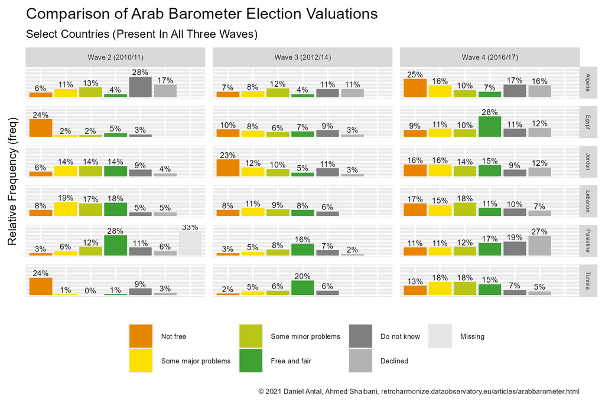

```r
knitr::include_graphics(
  here('vignettes', 'arabb-comparison-select-country-chart.png')
)
```

## Importing Arab Barometer Files

```r
### use here your own <arabbarometer_dir> directory
ab <- dir(arabbarometer_dir, pattern = "sav$")
arabbarometer_rounds <- here(arabbarometer_dir, ab)
arab_waves <- read_surveys(arabbarometer_rounds, .f='read_spss')
```

we appended meaningful identifiers to the file names as follows (you must follow the ordering of your files in your own `arabbarometer_dir` dir):

```r
# In the vignette this is pre-loaded.
attr(arab_waves[[1]],"id") <- "Arab_Barometer_5"
attr(arab_waves[[2]],"id") <- "Arab_Barometer_1"
attr(arab_waves[[3]],"id") <- "Arab_Barometer_2"
attr(arab_waves[[4]],"id") <- "Arab_Barometer_3"
attr(arab_waves[[5]],"id") <- "Arab_Barometer_4"
```

We use `document_waves()`to see the primary descriptive information of our survey wave (one harmonized survey set) files. Visually check that the file names correspond with the meaningful IDs that you gave to each survey wave, i.e., `Arab_Barometer_1` corresponds with `ABI_English.sav`.

```r
# In the vignette this is pre-loaded.
documented_arab_waves <- document_waves(arab_waves)
```

```r
print(documented_arab_waves)
```

```
#> # A tibble: 5 x 5
#>   id               filename           ncol  nrow object_size
#>   <chr>            <chr>             <int> <int>       <dbl>
#> 1 Arab_Barometer_5 AB-WaveV-EN.sav     348 26780    78131600
#> 2 Arab_Barometer_1 ABI_English.sav     182  7337    12089512
#> 3 Arab_Barometer_2 ABII_English.sav    469 12782    51603152
#> 4 Arab_Barometer_3 ABIII_English.sav   297 14809    37826816
#> 5 Arab_Barometer_4 ABIV_English.sav    291  9000    23315888
```

We obtained 5 nested lists in the `arab_waves` list, each of them containing data of one Arab Barometer survey wave (the same surveys taken roughly at the same time, and with the same questions in different languages and countries.). To create longitudinal tables, i.e., join several survey waves into a single table, it is important to review the methodology of each round of Arabbarometer’s surveys, its structure, modifications, and changes in topics of interest.

### Joint Metadata Creation

In this step, we build a comprehensive metadata table that maps information about variable names and labels of the survey data. Each row in the table below refers to a different variable in the survey data file. This is accomplished using the `metadata_create()` function, which collects metadata from survey data files, normalizes variable labels, and defines the valid and missing value ranges, codes, and labels.

```r
# In the vignette this is pre-loaded.
arabbarometer_metadata <- lapply ( X = arab_waves, FUN = metadata_create)
arabbarometer_metadata <- do.call(rbind, arabbarometer_metadata)
```

Let’s randomly review some metadata:

```r
set.seed(2021)
arabbarometer_metadata %>%
  select (-all_of(c("filename", "class_orig"))) %>%
  sample_n(6)
```

```
#>                 id var_name_orig
#> 1 Arab_Barometer_2         q7112
#> 2 Arab_Barometer_5        Q521_1
#> 3 Arab_Barometer_4    aid1b1lang
#> 4 Arab_Barometer_1         q2572
#> 5 Arab_Barometer_2         q5164
#> 6 Arab_Barometer_2         eg802
#>                                                                                                                                                 label_orig
#> 1 q7112 to what extent do you agree or disagree with the following statements 2 in order to eliminate global terrorism, the palestine issue must be solved
#> 2                                                                                                                   guaranteed freedoms opinion expression
#> 3                                                                                                       aid1b1 respondent participated in language program
#> 4                                                                                     q257 2 can you remember the name of the speaker leader of parliament
#> 5 q5164 to what extent do you agree or disagree with the following statements 4 a democratic system may have problems, yet it is better than other systems
#> 6                                eg802 did you participate in the protests against former president hosni mubarak between january 25 and february 11, 2011
#>                labels        valid_labels na_labels na_range n_labels
#> 1 0, 1, 2, 3, 4, 8, 9 0, 1, 2, 3, 4, 8, 9                 NA        7
#> 2  1, 2, 3, 4, 98, 99  1, 2, 3, 4, 98, 99                 NA        6
#> 3                0, 1                0, 1                 NA        2
#> 4    1, 2, 97, 98, 99    1, 2, 97, 98, 99                 NA        5
#> 5 0, 1, 2, 3, 4, 8, 9 0, 1, 2, 3, 4, 8, 9                 NA        7
#> 6       0, 1, 2, 8, 9       0, 1, 2, 8, 9                 NA        5
#>   n_valid_labels n_na_labels
#> 1              7           0
#> 2              6           0
#> 3              2           0
#> 4              5           0
#> 5              7           0
#> 6              5           0
```

We select from the metadata file `rowid` as the unique observation identifier, and some auxiliary variables: `date` with the interview date,the `COUNTRY` containing country where the interview was conducted, and `wt` as the weighting factor, and some “real” survey questions. The countries in the Arab Barometer datasets are countries from the Middle East and North Africa (MENA) region with a significant Arab speaking population. The data does not contain all the MENA countries, for example, Palestine is present in the dataset, but Israel is not.

The metadata table also helps you to identify survey items of interest; in our case, we chose *Election, parliamentary*, and *Election* to fork an exact question about parliamentary election, which is `How would you evaluate the last parliamentary election?`

## Retrospective Survey Harmonization

Retrospective survey harmonization has two steps: variable harmonization and label harmonization.

### Harmonizing the variable names

We start with the variable harmonization process.

```r
to_harmonize_elections <- arabbarometer_metadata %>%
  filter( .data$var_name_orig %in% c("rowid", "country","date", "wt")|
           grepl("how would you evaluate the last parliamentary", .data$label_orig)) %>%
  mutate(var_label = var_label_normalize(.data$label_orig)) %>%
  mutate(var_label = case_when(
    .data$var_name_orig == "country" ~ "Country",
    .data$var_name_orig == "rowid"   ~ "Unique ID AB English", # in pdf Unique ID AB English
    .data$var_name_orig == "date"    ~ "Date_of_interview",
    .data$var_name_orig == "wt"      ~ "Weight",
    TRUE ~ " Evaluation in the last parliamentary elections")) %>%
  mutate ( var_name = var_label_normalize(.data$var_label) )

set.seed(2021) # Let's see the same random example:
sample_n(to_harmonize_elections%>%
       select ( all_of(c("id", "var_name", "var_label"))), 10)
```

```
#>                  id                                       var_name
#> 1  Arab_Barometer_2                           unique id ab english
#> 2  Arab_Barometer_1                                        country
#> 3  Arab_Barometer_3                                         weight
#> 4  Arab_Barometer_2                                         weight
#> 5  Arab_Barometer_4 evaluation in the last parliamentary elections
#> 6  Arab_Barometer_3                                        country
#> 7  Arab_Barometer_5                              date_of_interview
#> 8  Arab_Barometer_4                                         weight
#> 9  Arab_Barometer_4                                        country
#> 10 Arab_Barometer_3                           unique id ab english
#>                                          var_label
#> 1                             Unique ID AB English
#> 2                                          Country
#> 3                                           Weight
#> 4                                           Weight
#> 5   Evaluation in the last parliamentary elections
#> 6                                          Country
#> 7                                Date_of_interview
#> 8                                           Weight
#> 9                                          Country
#> 10                            Unique ID AB English
```

- Variable harmonization means that the date of the interview should be called exactly the same way in each survey table, i.e. not `date` and `date_of_interview`, only `date_of_interview`. The auxiliary and demography variables appear to be relatively well harmonized in the Arab Barometer, but the other survey items will require more work.
- Label harmonization means that the label for *Algeria* in the `country` variable must be a single value, for example, `Algeria`, instead of `Algeria`, `algeria`, `1. Algeria`.

In this case, the variable name harmonization is a simple task. The names need a bit of normalization for programmatic use.

The function `merge_waves()` harmonizes the variable names, the variable labels, the survey identifiers, and returns a list of surveys (of `class survey()`.) The parameter *var_harmonization* must be a list or a data frame that contains at least the original file name (`filename`), original variable names (`var_name_orig`), the new variable names (`var_name`) and their labels (`var_label`), so that the function correctly makes the harmonization steps.

```r
# In the vignette this is pre-loaded.
merged_ab_elections <- merge_waves(
  waves = arab_waves,
  var_harmonization = to_harmonize_elections)
```

```r
document_waves(merged_ab_elections)
```

```
#> # A tibble: 5 x 5
#>   id               filename           ncol  nrow object_size
#>   <chr>            <chr>             <int> <int>       <dbl>
#> 1 Arab_Barometer_5 AB-WaveV-EN.sav       4 26780     2991624
#> 2 Arab_Barometer_1 ABI_English.sav       2  7337      694064
#> 3 Arab_Barometer_2 ABII_English.sav      4 12782     1443896
#> 4 Arab_Barometer_3 ABIII_English.sav     5 14809     1790104
#> 5 Arab_Barometer_4 ABIV_English.sav      4  9000     1017088
```

Let’s take a look at the variables:

```r
lapply (merged_ab_elections, names)
```

```
#> [[1]]
#> [1] "unique id ab english" "country"              "weight"
#> [4] "date_of_interview"
#>
#> [[2]]
#> [1] "unique id ab english" "country"
#>
#> [[3]]
#> [1] "unique id ab english"
#> [2] "country"
#> [3] "evaluation in the last parliamentary elections"
#> [4] "weight"
#>
#> [[4]]
#> [1] "unique id ab english"
#> [2] "country"
#> [3] "date_of_interview"
#> [4] "weight"
#> [5] "evaluation in the last parliamentary elections"
#>
#> [[5]]
#> [1] "unique id ab english"
#> [2] "country"
#> [3] "weight"
#> [4] "evaluation in the last parliamentary elections"
```

The variable harmonization took place, but the variable names are not very practical for programmatic use. We apply `snakecase` variable naming:

```r
library(snakecase)
merged_ab_elections  <- lapply(
  merged_ab_elections,
  FUN = function(df) df %>%
                       rename_all(snakecase::to_snake_case)
  )
```

Now the variable names are ready to use in the programmatic way:

```r
lapply(merged_ab_elections, names)
```

```
#> [[1]]
#> [1] "unique_id_ab_english" "country"              "weight"
#> [4] "date_of_interview"
#>
#> [[2]]
#> [1] "unique_id_ab_english" "country"
#>
#> [[3]]
#> [1] "unique_id_ab_english"
#> [2] "country"
#> [3] "evaluation_in_the_last_parliamentary_elections"
#> [4] "weight"
#>
#> [[4]]
#> [1] "unique_id_ab_english"
#> [2] "country"
#> [3] "date_of_interview"
#> [4] "weight"
#> [5] "evaluation_in_the_last_parliamentary_elections"
#>
#> [[5]]
#> [1] "unique_id_ab_english"
#> [2] "country"
#> [3] "weight"
#> [4] "evaluation_in_the_last_parliamentary_elections"
```

The `merged_ab_elections` is a list, which nests the individual, subsetted surveys. We use the nested list form, because a critical step is missing: the survey have differing number of columns, so they cannot be joined into a long-form, tidy data frame. Let’s remove the nonessential variables, and remove the survey waves that do not contain our variable of interest.

In our case, we decided to: - omit completely both waves 1 and 5, because none of them has our key variable `Parliamentary Election Evaluation`; - omit `date of interview` as it is missing in both waves (rounds) 2 and 4.

```r
ab_elections <- merged_ab_elections[-c(1,2)]
lapply ( ab_elections, function(x)  attributes(x)$id )
```

```
#> [[1]]
#> [1] "Arab_Barometer_2"
#>
#> [[2]]
#> [1] "Arab_Barometer_3"
#>
#> [[3]]
#> [1] "Arab_Barometer_4"
```

```r
ab_elections <- lapply(ab_elections, function(x){
  if ("date_of_interview" %in% names(x)){
    subset(x, select = -c(date_of_interview))
  } else{
    subset(x)
  }
})
```

```r
document_waves(ab_elections)
```

```
#> # A tibble: 3 x 5
#>   id               filename           ncol  nrow object_size
#>   <chr>            <chr>             <int> <int>       <dbl>
#> 1 Arab_Barometer_2 ABII_English.sav      4 12782     1443896
#> 2 Arab_Barometer_3 ABIII_English.sav     4 14809     1670608
#> 3 Arab_Barometer_4 ABIV_English.sav      4  9000     1017088
```

### Variable Label Harmonization

The R language uses special NA values for missing values. These are differently encoded in SPSS, and in various survey programs unfortunately are not always consistently used. Compared to our Eurobarometer and Afrobarometer use cases, the Arab Barometer needs particularly lot of harmonization, because - The published Arab Barometer files do not contain either missing range, nor the explicitly stated missing cases, and the values that refer to various missing cases are mixed with valid values; - The missing cases, like the valid cases, are labelled inconsistently.

Our variable label harmonization therefore takes two steps: carefully labelling and removing the missing cases from the valid range, and then harmonizing the valid value labels.

Arabbarometer’s SPSS files use various missing value categories, we must carefully harmonize them, too. The entire value range is the following:

```r
collect_val_labels(
  to_harmonize_elections %>%
     filter(grepl("evaluation in the last parliamentary elections",
                  .data$var_name))
  )
```

```
#>  [1] "0. missing"
#>  [2] "1. they were completely free and fair"
#>  [3] "2. they were free and fair, with some minor problems"
#>  [4] "3. they were free and fair, with some major problems"
#>  [5] "4. they were not free and fair"
#>  [6] "8. i don't know"
#>  [7] "9. declined to answer"
#>  [8] "Missing"
#>  [9] "They were completely free and fair"
#> [10] "They were free and fair, with some minor breaches"
#> [11] "They were free and fair, with some major breaches"
#> [12] "They were not free and fair"
#> [13] "Don't know"
#> [14] "Refuse"
#> [15] "Completely free and fair"
#> [16] "Free and fair, but with minor problems"
#> [17] "Free and fair, with major problems"
#> [18] "Not free or fair"
#> [19] "Don't know (Do not read)"
#> [20] "Decline to answer (Do not read)"
```

For example, `Refuse` and `Decline to answer (Do not read)` are categories when the interviewee refused to form an opinion. This is a different case from `Missing`: in Saudi Arabia, there were not parliamentary elections, therefore the question was not asked from interviewees in this country.

The question of interest `How would you evaluate the last parliamentary election?` is described as a closed form survey questions where answers are predetermined and the respondents chose one of the answer options. This question has four-point ordinal scales, therefore, data is best to analyzed in an ordinal representation that does not assume equidistant values (i.e., as factors.)

We created the following retrospective labelling and coding:

The harmonization function from the `harmonize_values()` is a prototype function. We could call it directly, but instead we create `harmonize_arabb_eval()` to avoid the complicated parameterization.

```r
harmonize_arabb_eval <- function(x){
  label_list <- list(
    from = c("(\\d\\.\\s)?(\\w+\\s\\w+\\s)?([c|C]ompletely free and fair)",
             "(.+)(but)?\\s?(with)\\s(some)?\\s{0,}(minor\\s\\w+)",
             "(.+)(but)?\\s?(with)\\s(some)?\\s{0,}(major\\s\\w+)",
             "(.+)?([n|N]ot\\sfree\\s\\w+\\s\\w+)",
             "((\\d.\\s{0,})?\\si\\s)?([d|D]on.t\\sknow)(\\s\\(Do\\snot\\sread\\))?",
             "[R|r]efuse",
             "(\\d.\\s)?[d|D]ecline[d]?(\\s\\w+\\s\\w+)(\\s.Do not read.)?",
             "(\\d.\\s)?[m|M]issing"),
    to = c("free_and_fair",
           "some_minor_problems",
           "some_major_problems",
           "not_free",
           "do_not_know","declined","declined","missing"),
    numeric_values = c(3,2,1,0,99997,99998,99998,99999))
  harmonize_values(x, harmonize_labels = label_list,
                   na_values = c("do_not_know"= 99997,
                                 "declined"=99998,
                                 "missing"=99999
                   ))
}
```

The problem is that the numeric codes are not only used for the evaluation question, but also for country names. Beware not to apply the election evaluation code tabel to the country names!

```r
harmonized_evaluations <- harmonize_waves(
  waves = lapply ( ab_elections, function(x) x %>%
                     select (-.data$country)),
  .f =harmonize_arabb_eval )
```

There is a bit of a work with the country variable, too, but this variable has no missing cases, and instead of creating a labelling, we will convert them into factors after cleaning. We only show a few examples of the labelling issues:

```r
country_labels <- collect_val_labels (to_harmonize_elections %>%
                      filter (.data$var_name == "country"))

country_labels[grepl("lgeria|orocco|oman" , country_labels)]
```

```
#> [1] "Algeria"     "Morocco"     "algeria"     "morocco"     "1. Algeria"
#> [6] "13. morocco" "14. oman"
```

Do not forget that our imported surveys use [our special vector class](https://retroharmonize.dataobservatory.eu/articles/labelled_spss_survey.html) to contain all *metadata* information that could be saved from the SPSS files. The base R `as.character` and `as.factor` methods should be avoided, because they do not understand the SPSS labels. Use the `as_character()` and `as_factor` methods clean the country names. We could use `harmonize_values()`,` too, but that would be a lot of work, because there are a lot of country labels present. So we only retain a factor representation of the country names, without keeping their labelling history.

```r
normalize_country_names <- function(x) {
  x <- trimws(gsub("\\d{1,}\\.\\s?","", tolower(as_character(x))), which = "both")
  as_factor(snakecase::to_title_case(x))}
```

```r
harmonize_countries <- lapply ( ab_elections,
                                function(x) x %>%
                                          select ( -.data$evaluation_in_the_last_parliamentary_elections)
                                )
harmonized_countries <- lapply ( harmonize_countries, function(x) x %>%
                mutate ( country = normalize_country_names(.data$country)) %>%
                select (-any_of("date_of_interview")))

harmonized_countries <- do.call (rbind, harmonized_countries)
```

Let’s see if there is any further work to do!

```r
summary(harmonized_countries)
```

```
#>  unique_id_ab_english      country          weight
#>  Length:36591         Jordan   : 4483   Min.   : 0.02837
#>  Class :character     Lebanon  : 4087   1st Qu.: 0.70908
#>  Mode  :character     Algeria  : 3636   Median : 0.96349
#>                       Egypt    : 3615   Mean   : 0.99928
#>                       Palestine: 3600   3rd Qu.: 1.17818
#>                       Tunisia  : 3595   Max.   :16.48268
#>                       (Other)  :13575   NA's   :1
```

```r
summary(harmonized_evaluations)
```

```
#>  Evaluation in the last parliamentary elections
#> Numeric values without coding:
#>    Min. 1st Qu.  Median    Mean 3rd Qu.    Max.    NA's
#>       0       0       2   15099       3   99999    2004
#> Numeric representation:
#>    Min. 1st Qu.  Median    Mean 3rd Qu.    Max.    NA's
#>   0.000   0.000   2.000   1.462   3.000   3.000    7226
#> Factor representation:
#>  unique_id_ab_english     weight
#>  Length:36591         Min.   : 0.02837
#>  Class :character     1st Qu.: 0.70908
#>  Mode  :character     Median : 0.96349
#>                       Mean   : 0.99928
#>                       3rd Qu.: 1.17818
#>                       Max.   :16.48268
#>                       NA's   :1
#>
#>  evaluation_in_the_last_parliamentary_elections
#>  not_free           :9453
#>  some_major_problems:4337
#>  some_minor_problems:8141
#>  free_and_fair      :7434
#>  do_not_know        :4954
#>  declined           : 262
#>  missing            :   6
#>  NA's               :2004
```

We see a missing weight, and we will impute 1 for this particular value, so that we can use weighted averaging in the numerical representation of our data.

```r
harmonized_ab_dataset <- harmonized_countries  %>%
  left_join(harmonized_evaluations, by = c("unique_id_ab_english", "weight") ) %>%
  rename ( eval_parl = .data$evaluation_in_the_last_parliamentary_elections) %>%
  mutate (
    wave = as_factor(gsub(".*(\\b[A-Z0-9]+).*", "\\1", .data$unique_id_ab_english)),
    weight = ifelse(is.na(.data$weight), 1, .data$weight),
    eval_parl = as_factor(.data$eval_parl),
    country = as_factor(.data$country))

summary(harmonized_ab_dataset)
```

```
#>  unique_id_ab_english      country          weight
#>  Length:36591         Jordan   : 4483   Min.   : 0.02837
#>  Class :character     Lebanon  : 4087   1st Qu.: 0.70908
#>  Mode  :character     Algeria  : 3636   Median : 0.96349
#>                       Egypt    : 3615   Mean   : 0.99928
#>                       Palestine: 3600   3rd Qu.: 1.17818
#>                       Tunisia  : 3595   Max.   :16.48268
#>                       (Other)  :13575
#>                eval_parl       wave
#>  not_free           :9453   ABII :12782
#>  some_minor_problems:8141   ABIII:14809
#>  free_and_fair      :7434   ABIV : 9000
#>  do_not_know        :4954
#>  some_major_problems:4337
#>  (Other)            : 268
#>  NA's               :2004
```

### Categorical And Numeric Coding

The labeled survey data was stored in `labelled_spss_survey()` vectors, which is a complex class that retains metadata for reproducibility, but most statistical packages work with numeric or categorical (factor) data. The data can be converted to any of these, but you should use the methods of `labelled_spss_survey()` for this purpose, i.e., `as_numeric()` or `as_factor()`. (See more why you should not fall back on the more generic as.factor() or as.numeric() methods in The [labelled_spss_survey class vignette](https://retroharmonize.dataobservatory.eu/articles/labelled_spss_survey.html).)

Due to the categorical format of the question of MENA parliamentary election evaluation in the Arab Barometer survey rounds, we decided to present the election variable in its *categorical* format. We show the unweighted tallies for each evaluation category, and a weighted sum, which the rounded number of the category counts multiplied by the respondent’s post-stratification weight.

```r
categorical_summary <- harmonized_ab_dataset %>%
  select ( -all_of(c("unique_id_ab_english")) )  %>%
  group_by ( .data$country, .data$wave, .data$eval_parl ) %>%
  summarize (n = n(),
             weighted = round(n*weight, 0)
             ) %>%
  ungroup()
```

```r
set.seed(2021)
categorical_summary %>% sample_n(12)
```

```
#> # A tibble: 12 x 5
#>    country wave  eval_parl               n weighted
#>    <fct>   <fct> <fct>               <int>    <dbl>
#>  1 Sudan   ABIII not_free              360      176
#>  2 Lebanon ABIV  some_minor_problems   412      341
#>  3 Lebanon ABIII free_and_fair         271      556
#>  4 Morocco ABIV  some_minor_problems   386      362
#>  5 Lebanon ABIV  some_minor_problems   412      377
#>  6 Lebanon ABII  some_major_problems   268      242
#>  7 Lebanon ABIII not_free              272      268
#>  8 Tunisia ABIV  free_and_fair         302      296
#>  9 Algeria ABII  do_not_know           407      326
#> 10 Morocco ABIII some_minor_problems   328      375
#> 11 Jordan  ABIII free_and_fair         172      410
#> 12 Sudan   ABIII not_free              360      439
```

The output as shown in the table above indicates the number of valuations given by interviewees to the election evaluation question, by country and by survey wave. In the table below (which we only print in part), we assign numeric values to the evaluation categories. To recall our simple coding: - `3` = Free and fair - `2` = Some minor problems - `1` = Some major problems - `0` = Not free.

```r
numeric_summary <- harmonized_ab_dataset %>%
  select ( -all_of(c("unique_id_ab_english")) )  %>%
  mutate ( eval_parl = as_numeric(.data$eval_parl)) %>%
  group_by ( .data$country, .data$wave ) %>%
  summarize (
    mean = weighted.mean(.data$eval_parl, w = .data$weight),
    median = median(.data$eval_parl)
  ) %>%
  ungroup()
```

In the numeric summary we show the weighted average valuations and the unweighted, typical values. These correspond with highest tallies for the categorical (and unweighted) counts.

```r
set.seed(2021)
numeric_summary %>% sample_n(12)
```

```
#> # A tibble: 12 x 4
#>    country wave   mean median
#>    <fct>   <fct> <dbl>  <dbl>
#>  1 Iraq    ABII   2.53      2
#>  2 Egypt   ABIV   3.38      4
#>  3 Lebanon ABIV  NA        NA
#>  4 Kuwait  ABIII  3.27      3
#>  5 Morocco ABIV   3.45      3
#>  6 Lebanon ABII   2.69      3
#>  7 Sudan   ABIII  2.59      3
#>  8 Morocco ABIII  2.82      3
#>  9 Tunisia ABIII  3.59      4
#> 10 Tunisia ABII   1.48      1
#> 11 Libya   ABIII  3.11      4
#> 12 Egypt   ABIII  2.88      3
```

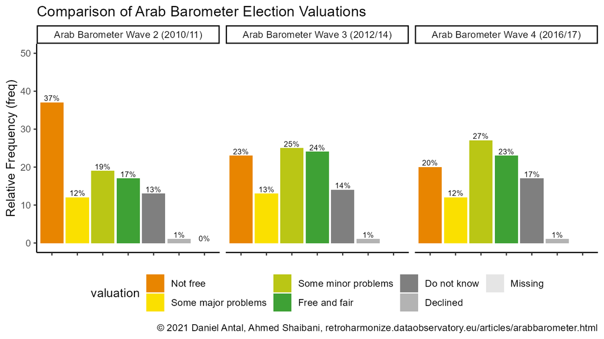

```r
knitr::include_graphics(
  here('vignettes', 'arabb-comparison-chart.png')
)
```

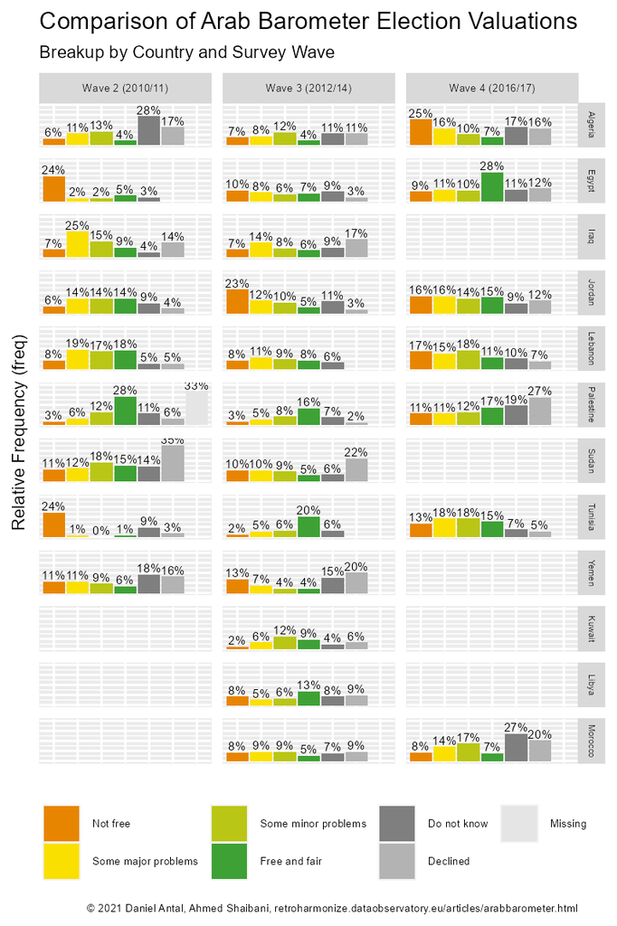

```r
knitr::include_graphics(
  here('vignettes', 'arabb-comparison-country-chart.png')
)
```

We release the harmonized datasets with the code and the tutorial for further review and potential corrections.

## Replication Data, Citations and Related work

### Replication Data

The used datafiles and the metadata tables, and harmonized tables are too large to be hosted in a released R package. We deposited the results for further review and potential improvements on from [Zenodo](https://doi.org/10.5281/zenodo.5034741). All comments are corrections are welcome.

```r
harmonized_ab_data <- harmonized_ab_dataset %>%
  rename ( id = .data$unique_id_ab_english ) %>%
  mutate (eval_parl_num = as_numeric(.data$eval_parl),
          eval_parl_cat = as_factor(.data$eval_parl)) %>%
  select (all_of(c("id", "country", "eval_parl_num", "eval_parl_cat", "wave")))
```

```r
haven::write_sav(data = harmonized_ab_data,
                 here("data-raw", "arabb", "harmonized_arabb_waves.sav"))
write.csv(harmonized_ab_data,
          here("data-raw", "arabb", "harmonized_arabb_waves.csv"),
          row.names=FALSE)
write.csv(categorical_summary,
          here("data-raw", "arabb",  "arabb_categorical_summary.csv"),
          row.names=FALSE)
write.csv(numeric_summary,
          here("data-raw", "arabb", "arabb_numeric_summary.csv"),
          row.names=FALSE)

# The metadata file contains list objects, which cannot be represented
# in a flat csv file format.
saveRDS(arabbarometer_metadata,
        here("data-raw", "arabb", "arabbarometer_metadata.rds")
        )

## The lists of value labels are dropped from the csv output.
write.csv(arabbarometer_metadata [
  , -which (sapply ( arabbarometer_metadata, class) == "list")],
  here("data-raw", "arabb","arabb_metadata_simplified.csv"), row.names=FALSE)
```

Daniel Antal, & Ahmed Shaibani. (2021). Replication Data for the retroharmonize R Package Case Study: Working With Arab Barometer Surveys (Version 0.1.6) [Data set]. Zenodo. https://doi.org/10.5281/zenodo.5034741

### Citing the data sources

Arab Barometer data: cite [Arab Barometer](https://www.arabbarometer.org/survey-data/data-downloads/).

### Citing the retroharmonize R package

For main developer and contributors, see the [package](https://retroharmonize.dataobservatory.eu/) homepage.

This work can be freely used, modified and distributed under the GPL-3 license:

```r
citation("retroharmonize")
```

```
#>
#>
#>   Daniel Antal (2021). retroharmonize: Ex Post Survey Data
#>   Harmonization. https://retroharmonize.dataobservatory.eu/,
#>   https://ropengov.github.io/retroharmonize/,
#>   https://github.com/rOpenGov/retroharmonize.
#>
#> A BibTeX entry for LaTeX users is
#>
#>   @Manual{,
#>     title = {retroharmonize: Ex Post Survey Data Harmonization},
#>     author = {Daniel Antal},
#>     year = {2021},
#>     note = {https://retroharmonize.dataobservatory.eu/,
#> https://ropengov.github.io/retroharmonize/,
#> https://github.com/rOpenGov/retroharmonize},
#>   }
```

### Contact

For contact information, see the [package](https://retroharmonize.dataobservatory.eu/) homepage.

### Version info

Daniel Antal, & Ahmed Shaibani. (2021, June 26). Case Study: Working With Arab Barometer Surveys for the retroharmonize R package (Version 0.1.6). Zenodo. https://doi.org/10.5281/zenodo.5034759